# Debugging

For the tasks below we want you to review the code provided. You will need to do a combination of the 3 things for each task:

Ensure the code is doing what is described in the goal description Fix any bugs/errors that occur in the code Rewrite parts/whole code to be written in a more efficient manner (think about things like not creating unnecessary objects, using tidyverse verbs and piping, making code as easy to read and understand). Some of the code chunks won’t have errors, but could be rewritten in a more efficient manner. There will be something to do on each code chunk.

For each task the expectation will be for you to provide:

written explanation about what you changed and why a copy of your new/improved code None of the code below has been evaluated so we want you to paste the code chunk into your project and test it out.

```r
library(tidyverse)
energy_scotland <- read_csv("data/energy_scotland.csv")
all_salaries <- read_csv("data/all_salaries.csv")
```

## Task 1

Goal: return the row in the data which has the maximum energy production, making sure the code would work if new data was added to the dataset.

```r
max(energy_scotland$energy_prod)
# this returns value 25165.9

energy_scotland %>%
  filter(energy_prod == 25165.9)
```

As the maximum energy production may change, I have replaced the current value with the code that would pull the current max value.It was possible to assign the max(energy_scotland$energy_prod) to an object and then use that object in the filter function however I have decided against it, as the current code is a simple one line operation that should not make the code unreadable.

```r
energy_scotland %>%
  filter(energy_prod == max(energy_scotland$energy_prod))
```

| year | sector | energy_prod |
| --- | --- | --- |
| 2017 | Renewables | 25165.9 |

## Task 2

Goal: create a new column called ‘rating’ to the energy table which will take the following values in the table. The bins should be inclusive of the upper value e.g. is the energy production is 20,000 exactly then will be ‘high’, if it’s 10,000 exactly then will be ‘medium’, etc.

lower energy production upper energy production rating 20000 very high 10000 20000 high 5000 10000 medium 2000 5000 low 2000 very low

```r
rating <- if_else(energy_scotland$energy_prod > 20000, "very high", if_else(energy_scotland$energy_prod > 10000 & energy_scotland$energy_prod <= 20000, "high", if_else(energy_scotland$energy_prod > 5000 & energy_scotland$energy_prod <= 10000, "medium", if_else(energy_scotland$energy_prod > 2000 & energy_scotland$energy_prod <= 5000, "low", "very low"))))

energy_scotland_rating <- bind_cols(energy_scotland, rating = rating)
```

I have simplified the code and added a new column in the first step using a mutate function.

```r
energy_scotland <- energy_scotland %>%
  mutate(rating = if_else(energy_prod > 20000, "very high",
                          if_else(energy_prod > 10000 & energy_prod <= 20000, "high",
                                  if_else(energy_prod > 5000 & energy_prod <= 10000, "medium",
                                          if_else(energy_prod > 2000 & energy_prod <= 5000, "low", "very low")
                                          )
                                  )
                          )
         )

energy_scotland
```

| year | sector | energy_prod | rating |
| --- | --- | --- | --- |
| 2006 | Gas | 10212.40 | high |
| 2010 | Renewables | 9501.36 | medium |
| 2012 | Oil | 639.06 | very low |
| 2013 | Renewables | 16989.60 | high |
| 2008 | Gas | 11607.86 | high |
| 2008 | Renewables | 9058.47 | medium |
| 2010 | Gas | 8380.64 | medium |
| 2016 | Coal | 2263.19 | low |
| 2012 | Gas | 5612.60 | medium |
| 2011 | Pumped hydro | 604.21 | very low |

[output cut: 68 more lines]

## Task 3

Goal: create a plot which shows how the energy production for the sectors renewables, gas and pumped hydro compare over time.

```r
renewable <- energy_scotland %>%
  filter(sector == "Renewables")

gas <- energy_scotland %>%
  filter(sector == "Gas")

hydro <- energy_scotland %>%
  filter(sector == "Pumped hydro")

years <- unique(energy_scotland$year)


ggplot() +
  geom_line(aes(x = year, y = energy_prod,  color = sector), data = renewable) +
  geom_line(aes(x = year, y = energy_prod, color = sector), data = gas) +
  geom_line(aes(x = year, y = energy_prod, color = sector), data = hydro) +
  scale_x_continuous(breaks = years) +
  labs(title = "Energy production in Scotland over time split by sector", x ="Year", y = "Energy production")
```

I have reduced the number of objects needed to created the plot and then shortened the ggplot part of the code.

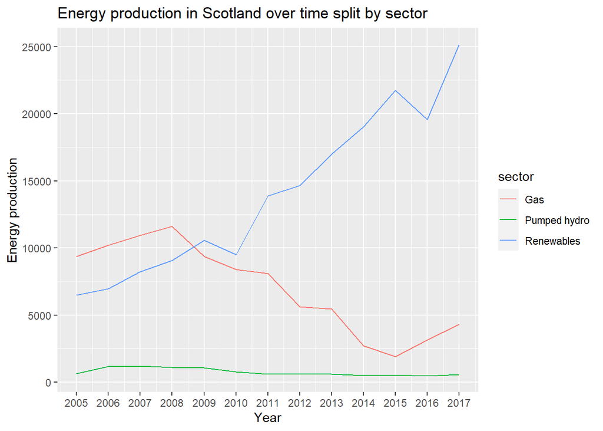

```r
energy_scotland %>%
  filter(sector %in% c("Renewables", "Gas", "Pumped hydro")) %>%
  ggplot(aes(x = year, y = energy_prod, colour = sector)) +
  geom_line()+
  scale_x_continuous(breaks = c(2005:2017)) +
  labs(title = "Energy production in Scotland over time split by sector", x = "Year", y = "Energy production")
```

## Task 4

Goal: calculate the average energy production for the Coal, Gas, and Oil sectors across the time period in the data.

```r
energy_scotland %>%
  filter(sector == c("Coal", "Gas", "Oil")) %>%
  group_by(sector) %>%
  summarise(avg_energy_prod = mean(energy_prod))
```

In the code above R compares only the first element of the sector with the entire vector, so I corrected it to make sure that data is filtered as desired and the mean is calculated properly.

```r
energy_scotland %>%
  filter(sector %in% c("Coal", "Gas", "Oil")) %>%
  group_by(sector) %>%
  summarise(avg_energy_prod = mean(energy_prod))
```

| sector | avg_energy_prod |
| --- | --- |
| Coal | 10444.602 |
| Gas | 7010.062 |
| Oil | 1154.682 |

## Task 5

Goal: clean up this tibble by only returning the name, location and email address information, putting the location information into lowercase and also creating a new column called valid_email to have values TRUE or FALSE whether the email address is valid. Here our definition is valid is that it contains an @ symbol followed by a combination of lowercase characters or a . symbol.

```r
student <- tibble(
  Name = c("Brian", "David", "Karen"),
  age = c(25, 56, 40),
  location = c("Scotland", "England", "scotland"),
  `email address` = c("briang@yahoo.co.uk", "dsmith@gmail.co.uk", "karen")
)

student
```

| Name | age | location | email address |
| --- | --- | --- | --- |
| Brian | 25 | Scotland | briang@yahoo.co.uk |
| David | 56 | England | dsmith@gmail.co.uk |
| Karen | 40 | scotland | karen |

```r
student %>%
  select(name, location, email_address) %>%
  janitor::clean_names() %>%
  str_to_lower(location)
  mutate(valid_email = str_detect(email_address, "@a-z.")
```

I have put *clean names* function first, to make sure the *select* function works as desired, then added *mutate* in order to make *str_to_lower* to work as intended and updated regex pattern to make sure it picks up the email address that is likely to be written in a correct format and returns true or false in the valid email column.

```r
student %>%
  janitor::clean_names() %>%
  select(name, location, email_address) %>%
  mutate(location = str_to_lower(location)) %>%
  mutate(valid_email = str_detect(email_address, "[a-z0-9_.]+@[a-z.]+"))
```

| name | location | email_address | valid_email |
| --- | --- | --- | --- |
| Brian | scotland | briang@yahoo.co.uk | TRUE |
| David | england | dsmith@gmail.co.uk | TRUE |
| Karen | scotland | karen | FALSE |

## Task 6

Goal: create a function to work on the all_salaries dataframe (or a similar dataframe that has a column salary and job_area). The function should take in the dataframe (dataframe_input) and a job area (job_area_input) and a salary value (salary_input). The function should only return the employees in the dataframe that have a salary above this value salary_input and who work in job area job_area_input. For example if job_area_input was ‘Legal’ and salary_input was 30000 then the function would return the following output:

```r
subsetting_salaries <- function(dataframe_input,job_area_input,salary_input){
  data <- dataframe_input %>% select(job_area) %>% filter(job_area == job_area_input)
  data1 <- data[data$savings > salary_input, ]
}

subsetting_salaries(CodeClanData::all_salaries, Human Resources, 30000)
```

I have removed *select* as I needed other columns in the output, then I have filtered data by salary being greater than salary input and added return (data1) to see the final output of the function. while testing the function I have removed *CodeClanData::* as all salaries wasn’t there and has already been assigned to an object called all _salaries (directly from a csv file). I have also added quotation marks to a character vector in order for the function to work.

```r
subsetting_salaries <- function(dataframe_input, job_area_input, salary_input){
  data <- dataframe_input %>% filter(job_area == job_area_input)
  data1 <- data %>% filter(salary > salary_input)
  return(data1)

}

subsetting_salaries(all_salaries, "Legal", 30000)
```

| gender | name | surname | job_area | salary | age | retired | location | savings |
| --- | --- | --- | --- | --- | --- | --- | --- | --- |
| Female | Helena | Johnson | Legal | 31000 | 76 | Yes | Aberdeen | 30924 |
| Female | Helena | Jamieson | Legal | 36000 | 27 | No | Western Isles | 50211 |
| Female | Dora | Robertson | Legal | 31000 | 88 | Yes | Orkney | 27883 |